# Exploratory data analysis for pig data

# Basic data cleaning

```r
# Load in the pig data
library(data.table)
dt = fread("../data/formatted/full_pig_data.csv")
```

Check for missing lat-long values. Hopefully the data cleaning has dealt with these…

```r
ind = is.na(dt$latitude) | is.na(dt$longitude)
sum(ind)
```

```
[1] 0
```

Recovert to datetime

```r
dt$datetime = as.POSIXct(dt$datetime, tz="GMT")
```

## Some exploratory data analysis

```r
length(unique(dt$pigID))
```

```
[1] 480
```

```r
dt[, list(numpigs=length(unique(pigID))), by="study"]
```

| study | numpigs |
| --- | --- |
| txcamp | 39 |
| florida | 58 |
| movepig | 219 |
| michigan | 9 |
| srel_vacuum | 21 |
| srs_kilgo | 12 |
| judas_pig | 17 |
| tejon | 15 |
| cali | 50 |
| srel_contact | 21 |

[output cut: 1 more lines]

We have 480 pigs, the `movepig` study site has 219 of these pigs.

Look at a plot of pigs in the USA

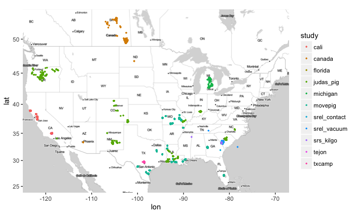

```r
library(ggmap)
meandat = dt[, list(meanlat = mean(latitude), meanlong = mean(longitude)), by="study"]
# All the pig data
us <- c(left = -125, bottom = 23.75, right = -67, top = 54)
map <- get_stamenmap(us, zoom = 5, maptype = "toner-lite")
plt = ggmap(map) + geom_point(data=dt[pigID != "canada679059BF21"], aes(x=longitude, y=latitude, color=study), size=0.5)
plt
ggsave("../results/datamap.jpg", width=8, height=5)
```

Something is up with Kilgo! We will need to figure that out. The Canada data also looks a little suspect…this is because the collars are recording when they are not on the animal.

```r
plt_can = ggmap(map) + geom_point(data=dt[dt$study == "canada" & dt$pigID == "canada679059B", ], aes(x=longitude, y=latitude, color=pigID), size=0.5)
plt_can
ggsave("../results/679059B.jpg", width=8, height=5)
```

```r
ggmap(map) + geom_point(data=dt[study == "tejon", ], aes(x=longitude, y=latitude))
```

Get the maximum time length at which fixings were taken for each individual pig

```r
fixinfo = dt[, list(study=unique(study),
                         deltat = max(datetime) - min(datetime),
                         numfixes=length(datetime),
                         start=min(datetime),
                         end=max(datetime)), by=list(pigID)]
ggplot(data=fixinfo) + geom_histogram(aes(x=deltat))
```

```r
fixinfo[which.max(deltat), ]
```

[output not shown]

```r
ggplot(data=fixinfo[study != "srs_kilgo", ]) + geom_histogram(aes(x=deltat))
```

Order by fix times.

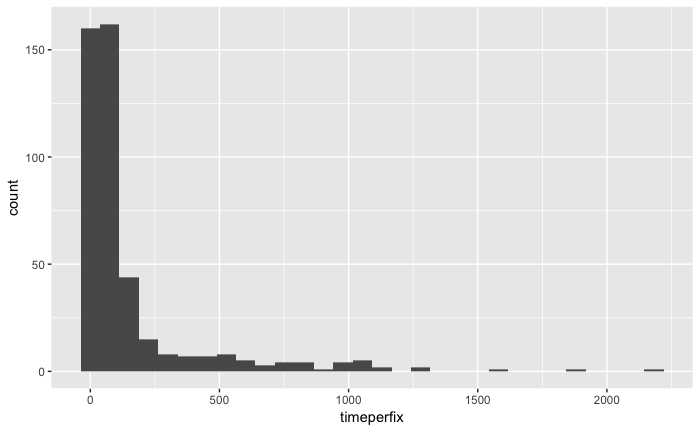

```r
fixinfo[, fixrate:= numfixes / as.numeric(deltat)]
fixinfo[, timeperfix:= (as.numeric(deltat) / numfixes)*24*60]
fixinfo[order(timeperfix, decreasing = F), ]
ggplot(data=fixinfo[study != "srs_kilgo"]) + geom_histogram(aes(x=timeperfix))
```

Look at how collaring times vary across studies

```r
studies = unique(fixinfo$study)

plots = list()
for(i in 1:length(studies)){

  plots[[i]] = ggplot(data=fixinfo[study==studies[i]], aes(pigID)) + geom_linerange(aes(ymin=start, ymax=end)) +
    facet_wrap(~study, scales = "free") + theme(axis.text.x = element_text(angle = 90, hjust = 1, size=8))
}
```

```r
for(i in 1:length(plots)){
  print(plots[[i]])
}
```

Some summary stats by study

```r
# Order the GPS colors by pig and time
dt = dt[order(pigID, datetime)]
diffs = dt[, list(deltat=mean(diff(datetime))), by=list(pigID)]

ggplot(diffs, aes(x=deltat / (60 * 24))) + geom_histogram() + xlab("Days")
```

[output not shown]

## Determining which sequences will be useful for movement analysis

Which pigs have a sequences of at least 10 where each fix is less than 1hr different from the previous fix?

```r
source("pigfxns.R")

long_pigs = dt_trun[, list(longdat=runs(datetime), study=unique(study)), by=pigID]
print(sum(long_pigs$longdat))
print(nrow(long_pigs))
table(long_pigs$study[long_pigs$longdat])
```

Let’s just focus on these pigs for now.

```r
# Subset data to only include pigs that have the right length of data
keys = long_pigs$pigID[long_pigs$longdat]

# Should be a cleaner and faster way to do this...perhaps with match
inds = rep(FALSE, nrow(dt_trun))
for(key in keys){
  inds = inds | (dt_trun$pigID == key)
}

# Remove the pigs that
movedt = dt_trun[inds]
```

```r
table(movedt$study)
```

## Plot pig movement trajectories for each study

```r
library(ggmap)

# All the pig data
us <- c(left = -125, bottom = 25.75, right = -67, top = 49)
map <- get_stamenmap(us, zoom = 5, maptype = "toner-lite")
ggmap(map) + geom_point(data=dt_trun, aes(x=longitude, y=latitude, color=study))
```

```r
# Pig data that will probably be useful for movement models
us <- c(left = -125, bottom = 25.75, right = -67, top = 49)
map <- get_stamenmap(us, zoom = 5, maptype = "toner-lite")
ggmap(map) + geom_point(data=movedt, aes(x=longitude, y=latitude))
```

Look at a plot of pig movement in Texas.

```r
library(dplyr)
txcamp = movedt[pigID == "20125txcamp"]
map = get_googlemap(center=c(lon=-98.53675, lat=29.74411), zoom=14, maptype="hybrid") %>% ggmap()
map = map + geom_path(data=txcamp, aes(x=longitude, y=latitude), size=0.5)
map
```

```r
# Single pig diff
pigdiff = diff(txcamp$datetime)

inds = pigdiff < 100 # String of booleans

  # Count runs
run_vect = rle(inds)
run_vect
```

```r
write.csv(movedt, "../data/formatted/pig_trajectories.csv")
```